# Genome-wide methylation analysis report

# Genome-wide methylation analysis report

- study: Pleural cfDNAm analysis of neutrophil.lymphoctye.ratio.platevariable
- author: Paul Yousefi
- date: 08 October, 2026

## Parameters

```
## $sig.threshold
## [1] 2.121143e-07
##
## $max.plots
## [1] 10
##
## $qq.inflation.method
## [1] "median"
##
## $practical.threshold
## [1] 4.472453e-05
```

## Sample characteristics

For continuous or ordinal variables, the “mean” column provides the mean and the “sd/%” column the standard deviation of the variable. For categorical variables, the “mean” column provides the number of samples with the given “value” and the “sd/%” column the percentage of samples with the given “value”.

| variable | value | mean | sd.. |
| --- | --- | --- | --- |
| neutrophil.lymphoctye.ratio |  | 6.484677 | 4.801692 |
| plate |  | 2.317073 | 1.034622 |
| sv1 |  | 8.820948e-20 | 0.05913124 |
| sv2 |  | -1.226386e-18 | 0.05913124 |
| sv3 |  | -2.338165e-19 | 0.05913124 |
| sv4 |  | -1.770113e-18 | 0.05913124 |
| sv5 |  | 6.131928e-19 | 0.05913124 |
| sv6 |  | -2.930356e-18 | 0.05913124 |
| sv7 |  | -4.838158e-18 | 0.05913124 |
| sv8 |  | -5.728375e-18 | 0.05913124 |
| sv9 |  | 2.485708e-18 | 0.05913124 |
| sv10 |  | 1.036773e-15 | 0.05913124 |

## Covariate associations

### Covariate plate

statistics

| var1 | var2 | F | p-value | R | p-value |
| --- | --- | --- | --- | --- | --- |
| neutrophil.lymphoctye.ratio | plate | 0.488951 | 0.4849659 | 0.0120505 | 0.8389278 |

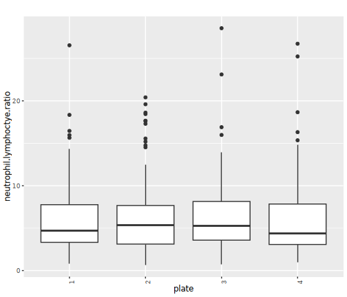

### Covariate sv1

statistics

| var1 | var2 | F | p-value | R | p-value |
| --- | --- | --- | --- | --- | --- |
| neutrophil.lymphoctye.ratio | sv1 | 1.736785 | 0.188605 | -0.0302411 | 0.6097097 |

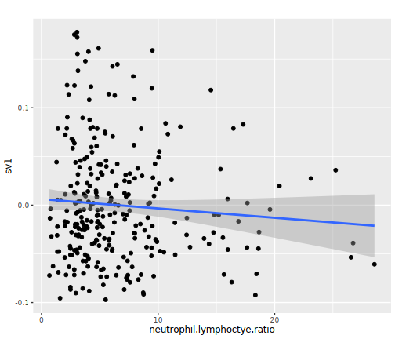

### Covariate sv2

statistics

| var1 | var2 | F | p-value | R | p-value |
| --- | --- | --- | --- | --- | --- |
| neutrophil.lymphoctye.ratio | sv2 | 0.9438985 | 0.3321011 | -0.0014061 | 0.9810697 |

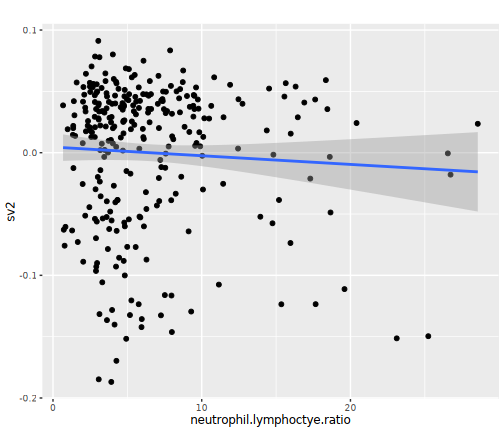

### Covariate sv3

statistics

| var1 | var2 | F | p-value | R | p-value |
| --- | --- | --- | --- | --- | --- |
| neutrophil.lymphoctye.ratio | sv3 | 0.9073641 | 0.3416219 | -0.0538877 | 0.3628209 |

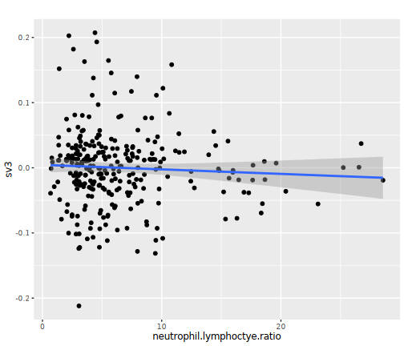

### Covariate sv4

statistics

| var1 | var2 | F | p-value | R | p-value |
| --- | --- | --- | --- | --- | --- |
| neutrophil.lymphoctye.ratio | sv4 | 0.3648359 | 0.5463132 | -0.0273461 | 0.6443653 |

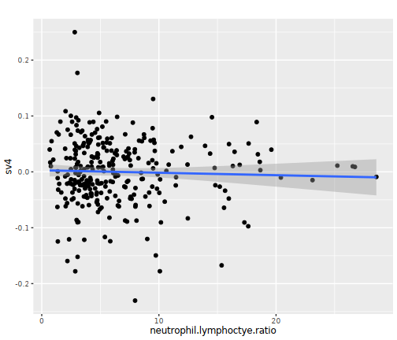

### Covariate sv5

statistics

| var1 | var2 | F | p-value | R | p-value |
| --- | --- | --- | --- | --- | --- |
| neutrophil.lymphoctye.ratio | sv5 | 1.494918 | 0.2224651 | -0.0658067 | 0.2663181 |

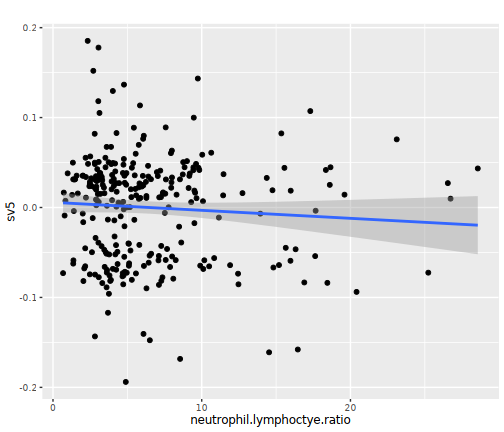

### Covariate sv6

statistics

| var1 | var2 | F | p-value | R | p-value |
| --- | --- | --- | --- | --- | --- |
| neutrophil.lymphoctye.ratio | sv6 | 0.8692037 | 0.351965 | 0.0523344 | 0.3768343 |

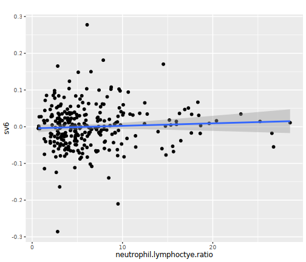

### Covariate sv7

statistics

| var1 | var2 | F | p-value | R | p-value |
| --- | --- | --- | --- | --- | --- |
| neutrophil.lymphoctye.ratio | sv7 | 0.8896262 | 0.3463775 | 0.0292152 | 0.6218966 |

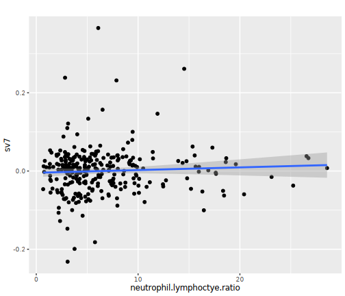

### Covariate sv8

statistics

| var1 | var2 | F | p-value | R | p-value |
| --- | --- | --- | --- | --- | --- |
| neutrophil.lymphoctye.ratio | sv8 | 0.059216 | 0.8079144 | -0.0247248 | 0.6764267 |

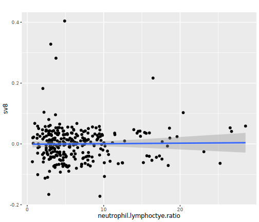

### Covariate sv9

statistics

| var1 | var2 | F | p-value | R | p-value |
| --- | --- | --- | --- | --- | --- |
| neutrophil.lymphoctye.ratio | sv9 | 2.151552 | 0.1435285 | -0.1211035 | 0.0403952 |

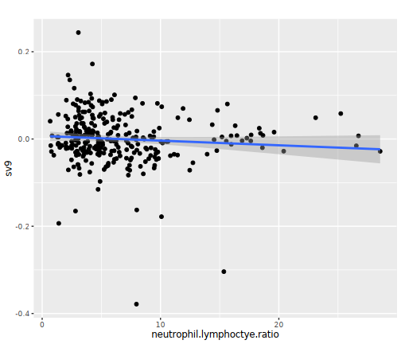

### Covariate sv10

statistics

| var1 | var2 | F | p-value | R | p-value |
| --- | --- | --- | --- | --- | --- |
| neutrophil.lymphoctye.ratio | sv10 | 0.2808869 | 0.5965331 | 0.0233765 | 0.693152 |

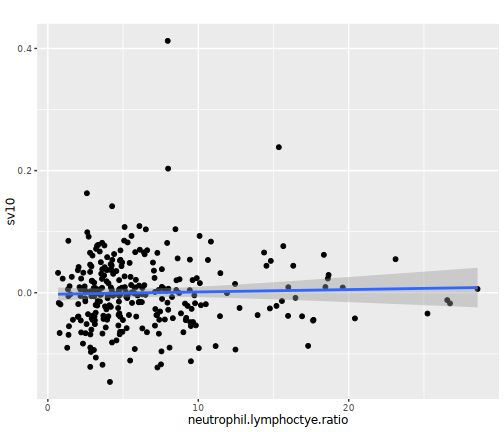

## QQ plots

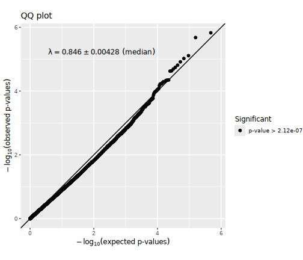

## Manhattan plots

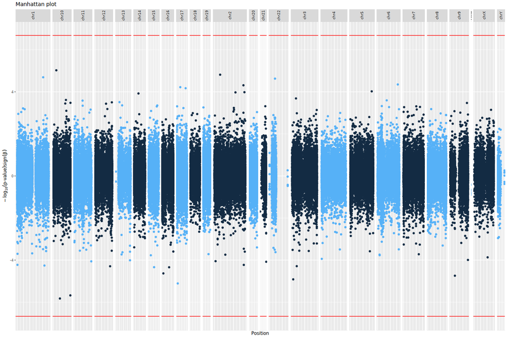

## Significant CpG sites

There were 0 CpG sites with association p-values < 2.1211427 × 10<sup>-7</sup>. These are listed in the file associations.csv.

Below are the 10 CpG sites with association p-values < 4.472453 × 10<sup>-5</sup> in the regression model.

|  | chromosome | position | estimate | p.value | p.adjust |
| --- | --- | --- | --- | --- | --- |
| cg09882128 | chr10 | 23727984 | 0.0013361 | 9.50e-06 | 1.0000000 |
| cg21127205 | chr16 | 10939326 | -0.0041060 | 2.32e-05 | 1.0000000 |
| cg04514631 | chr3 | 9289309 | -0.0072531 | 1.21e-05 | 1.0000000 |
| cg22160984 | chr17 | 9010812 | -0.0073877 | 7.70e-06 | 1.0000000 |
| cg13613745 | chr9 | 36728608 | -0.0047320 | 1.80e-05 | 1.0000000 |
| cg26426564 | chr10 | 134371746 | -0.0061064 | 2.10e-06 | 0.4926555 |
| cg09541576 | chr2 | 44873248 | 0.0054157 | 1.54e-05 | 1.0000000 |
| cg15045374 | chr10 | 52263678 | -0.0050942 | 1.50e-06 | 0.3498858 |
| cg27318474 | chr1 | 205290233 | 0.0023716 | 2.03e-05 | 1.0000000 |
| cg23761970 | chr22 | 42765709 | 0.0025440 | 2.36e-05 | 1.0000000 |

Plots of these sites follow, one for each covariate set. “p[lm]” denotes the p-value obtained using a linear model and “p[beta]” the p-value obtained using beta regression.

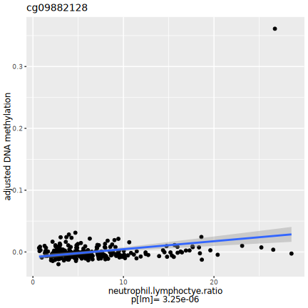

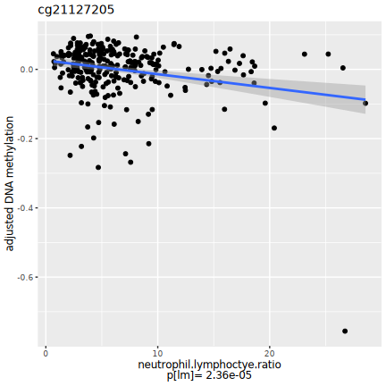

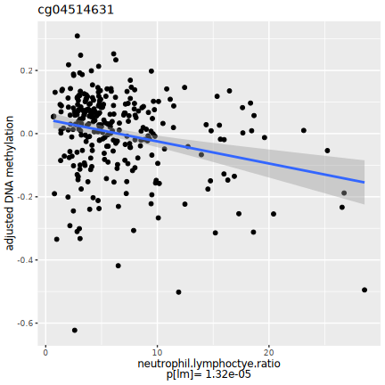

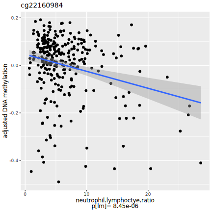

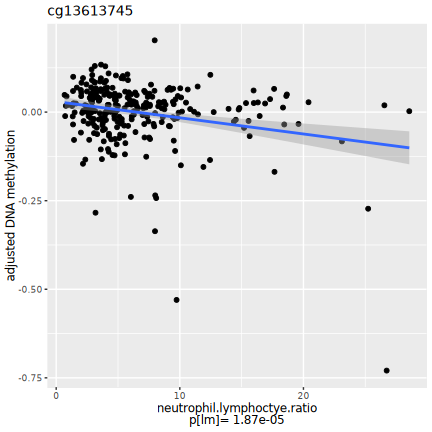

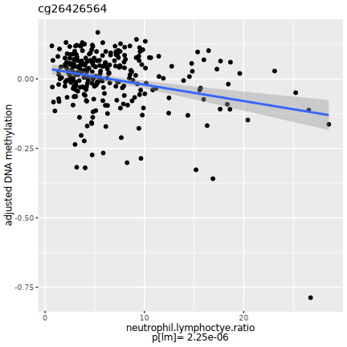

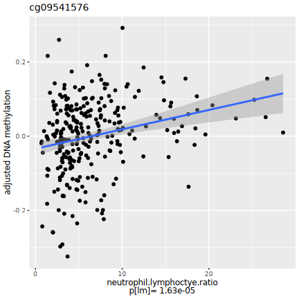

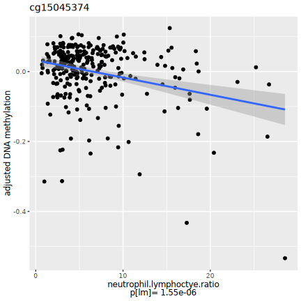

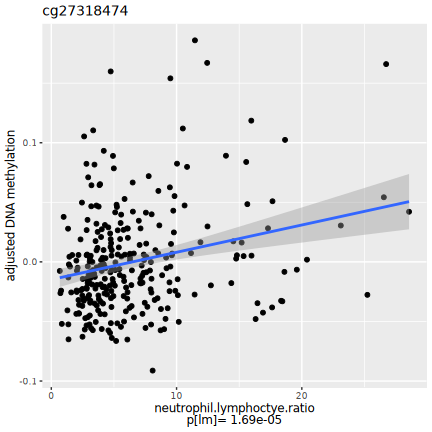

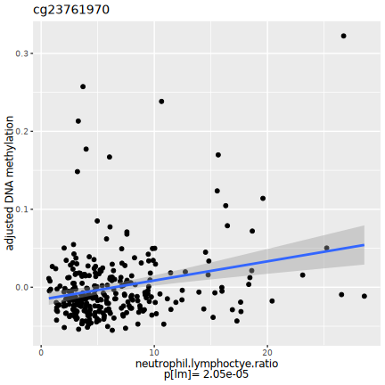

## Selected CpG sites

Number of CpG sites selected: 0.

| chromosome | position | estimate | p.value | p.adjust |
| --- | --- | --- | --- | --- |